# AllLife_Credit_Card_Customer_Segmentation_project_5

```python
## creating a new dataframe only for labels and converting it into categorical variable
df_labels_KC = pd.DataFrame(kmeans.labels_ , columns = list(['labels']))
df_labels_KC['labels'] = df_labels_KC['labels'].astype('category')

# Joining the label dataframe with the data frame.
df_labeled_KC = df.join(df_labels_KC)

# the groupby creates a groupeddataframe that needs to be converted back to dataframe
df_analysis = df_labeled_KC.groupby(['labels'])
df_analysis.mean()
```

| labels | Avg_Credit_Limit | Total_Credit_Cards | Total_visits_bank | Total_visits_online | Total_calls_made |
| --- | --- | --- | --- | --- | --- |
| 0 | 12174.107143 | 2.410714 | 0.933036 | 3.553571 | 6.870536 |
| 1 | 33782.383420 | 5.515544 | 3.489637 | 0.981865 | 2.000000 |
| 2 | 141040.000000 | 8.740000 | 0.600000 | 10.900000 | 1.080000 |

Insights:

1. Customers with high avg credit limit , have more no. of credit cards, often visit online and make less no. of calls to bank are belongs to label 2.
2. Customers with avg credit limit ,often visits Bank and making avearge no. of calls to the bank are belongs to label 1.
3. Customers with low avg credit limit , have less no. of credit cards, and made more no. of calls to bank are belongs to label 0.

```python
df_labeled_KC = df_Scaled.join(df_labels_KC) # Joining the label dataframe with the scaled data frame.*
```

```python
df_labeled_KC['labels'].value_counts()
```

```
1    386
0    224
2     50
Name: labels, dtype: int64
```

```
array([[<matplotlib.axes._subplots.AxesSubplot object at 0x0000021DDC3203A0>,
      dtype=object)
```

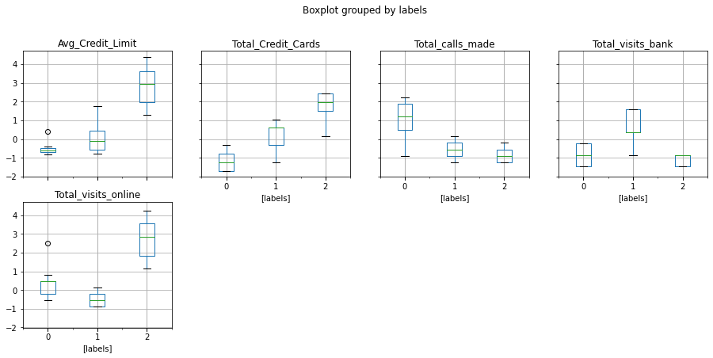

```python
# Visualize the centers
df_labeled_KC.boxplot(by = 'labels',  layout=(3,4), figsize=(15, 10))
```

Insights:

```python
# Calculate Avg Silhoutte Score

from sklearn.metrics import silhouette_score
silhouette_score(df_Scaled,kmeans.labels_)
```

```
0.5157182558881063
```

```python
#Set the value of k=5
kmeans = KMeans(n_clusters=5, n_init = 15, random_state=1)

kmeans.fit(df_Scaled)

centroids = kmeans.cluster_centers_
centroids
```

```
array([[-0.58417286, -1.03550272, -1.00241362,  0.37101896,  1.74956516],
       [ 0.04484302,  0.39006691,  0.05634061, -0.5631428 , -0.53162124],
       [ 2.83176409,  1.86222621, -1.10576269,  2.82731942, -0.87432983],
       [-0.08904777,  0.35679514,  1.29571325, -0.54390138, -0.5750638 ],
       [-0.60661802, -1.08207939, -0.80758165,  0.27828648,  0.58813224]])
```

```python
#Calculate the centroids for the columns to profile
centroid_df = pd.DataFrame(centroids, columns = list(df) )
print(centroid_df)
```

```
   Avg_Credit_Limit  Total_Credit_Cards  Total_visits_bank  \
0         -0.584173           -1.035503          -1.002414
1          0.044843            0.390067           0.056341
2          2.831764            1.862226          -1.105763
3         -0.089048            0.356795           1.295713
4         -0.606618           -1.082079          -0.807582

   Total_visits_online  Total_calls_made
0             0.371019          1.749565
1            -0.563143         -0.531621
2             2.827319         -0.874330
3            -0.543901         -0.575064
4             0.278286          0.588132
```

```python
## creating a new dataframe only for labels and converting it into categorical variable
df_labels_KC = pd.DataFrame(kmeans.labels_ , columns = list(['labels']))
df_labels_KC['labels'] = df_labels_KC['labels'].astype('category')

# Joining the label dataframe with the data frame.
df_labeled_KC = df.join(df_labels_KC)

# the groupby creates a groupeddataframe that needs to be converted back to dataframe
df_analysis = df_labeled_KC.groupby(['labels'])
df_analysis.mean()
```

| labels | Avg_Credit_Limit | Total_Credit_Cards | Total_visits_bank | Total_visits_online | Total_calls_made |
| --- | --- | --- | --- | --- | --- |
| 0 | 12611.111111 | 2.462963 | 0.768519 | 3.694444 | 8.592593 |
| 1 | 36260.204082 | 5.551020 | 2.494898 | 0.954082 | 2.061224 |
| 2 | 141040.000000 | 8.740000 | 0.600000 | 10.900000 | 1.080000 |
| 3 | 31226.315789 | 5.478947 | 4.515789 | 1.010526 | 1.936842 |
| 4 | 11767.241379 | 2.362069 | 1.086207 | 3.422414 | 5.267241 |

```python
df_labeled_KC = df_Scaled.join(df_labels_KC) # Joining the label dataframe with the scaled data frame.*
```

```python
df_labeled_KC['labels'].value_counts()
```

```
1    196
3    190
4    116
0    108
2     50
Name: labels, dtype: int64
```

```
array([[<matplotlib.axes._subplots.AxesSubplot object at 0x0000021DDDAB6A90>,
      dtype=object)
```

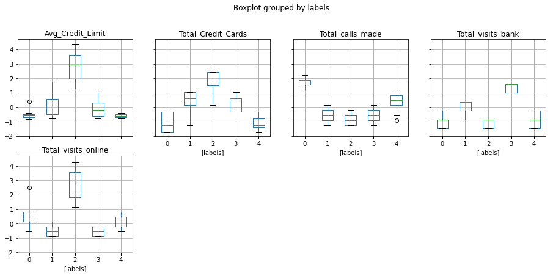

```python
# Visualize the centers
df_labeled_KC.boxplot(by = 'labels',  layout=(3,4), figsize=(15, 10))
```

```python
# Calculate Avg Silhoutte Score
silhouette_score(df_Scaled,kmeans.labels_)
```

```
0.27251438929461136
```

Insights: We can see that best silhouette_score is for k=3 . So, we will go with no.of clusters=3.

Hierarchical Clustering:

```python
from scipy.cluster.hierarchy import cophenet, dendrogram, linkage
from scipy.spatial.distance import pdist #Pairwise distribution between data points
```

```python
# cophenet index is a measure of the correlation between the distance of points in feature space and distance on dendrogram
# closer it is to 1, the better is the clustering

#### generate the linkage matrix for avearge linkage

Z = linkage(df_Scaled,'average', metric='euclidean')
c, coph_dists = cophenet(Z , pdist(df_Scaled))

c
```

```
0.8977080867389372
```

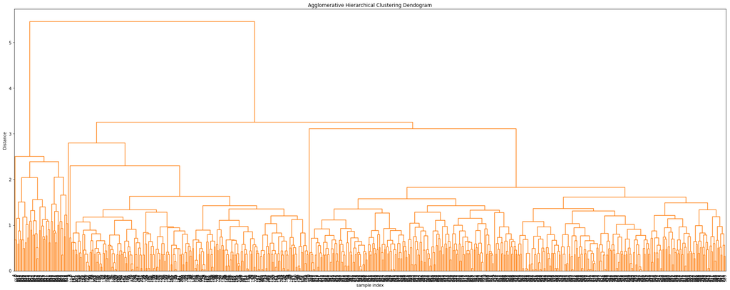

```python
plt.figure(figsize=(25, 10))
plt.title('Agglomerative Hierarchical Clustering Dendogram')
plt.xlabel('sample index')
plt.ylabel('Distance')
dendrogram(Z, leaf_rotation=90.,color_threshold=90,  leaf_font_size=10. )
plt.tight_layout()
# truncate_mode='lastp',
```

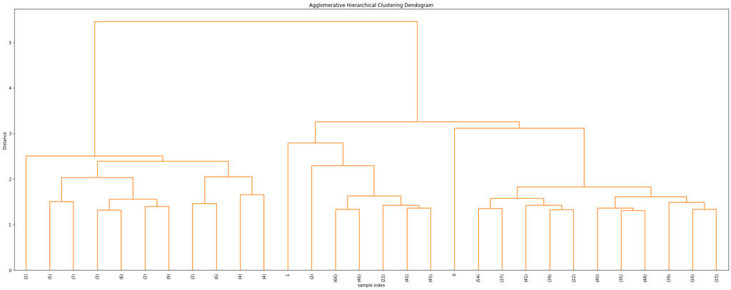

```python
# truncate_mode
plt.figure(figsize=(25, 10))
plt.title('Agglomerative Hierarchical Clustering Dendogram')
plt.xlabel('sample index')
plt.ylabel('Distance')
dendrogram(Z,truncate_mode='lastp', leaf_rotation=90.,color_threshold=90,  leaf_font_size=10. )
plt.tight_layout()
```

```python
#### generate the linkage matrix for complete linkage

Z = linkage(df_Scaled, 'complete', metric='euclidean')
c, coph_dists = cophenet(Z , pdist(df_Scaled))

c
```

```
0.8599730607972423
```

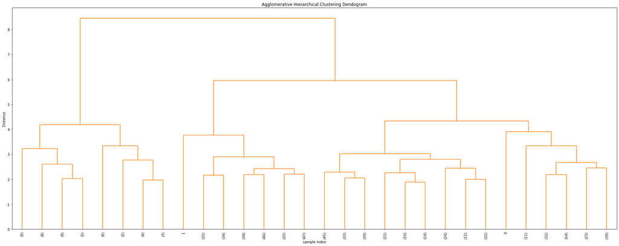

```python
# truncate_mode
plt.figure(figsize=(25, 10))
plt.title('Agglomerative Hierarchical Clustering Dendogram')
plt.xlabel('sample index')
plt.ylabel('Distance')
dendrogram(Z, truncate_mode='lastp',leaf_rotation=90.,color_threshold=90,  leaf_font_size=10. )
plt.tight_layout()
```

```python
#### generate the linkage matrix for single linkage
Z = linkage(df_Scaled, 'single', metric='euclidean')
c, coph_dists = cophenet(Z , pdist(df_Scaled))

c
```

```
0.7391220243806552
```

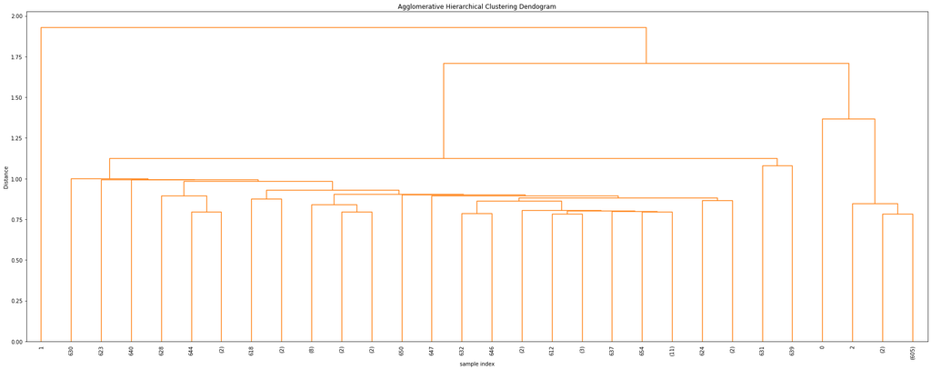

```python
#truncate_mode
plt.figure(figsize=(25, 10))
plt.title('Agglomerative Hierarchical Clustering Dendogram')
plt.xlabel('sample index')
plt.ylabel('Distance')
dendrogram(Z,truncate_mode='lastp', leaf_rotation=90.,color_threshold=90,  leaf_font_size=10. )
plt.tight_layout()
```

```python
#### generate the linkage matrix for ward linkage
Z = linkage(df_Scaled, 'ward', metric='euclidean')
c, coph_dists = cophenet(Z , pdist(df_Scaled))

c
```

```
0.7415156284827493
```

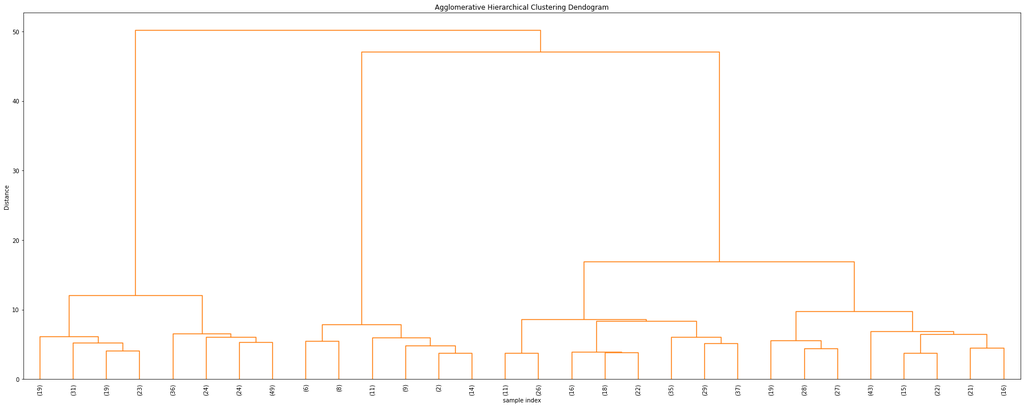

```python
# truncate_mode
plt.figure(figsize=(25, 10))
plt.title('Agglomerative Hierarchical Clustering Dendogram')
plt.xlabel('sample index')
plt.ylabel('Distance')
dendrogram(Z, truncate_mode='lastp',leaf_rotation=90.,color_threshold=90,  leaf_font_size=10. )
plt.tight_layout()
```

Insights: We can clearly see that best linkage method is average with cophenet index= 89.77%.

```python
from sklearn.cluster import AgglomerativeClustering
model = AgglomerativeClustering(n_clusters=2,affinity='euclidean', linkage='average')
model.fit(df_Scaled)
```

```
AgglomerativeClustering(linkage='average')
```

```python
## creating a new dataframe only for labels and converting it into categorical variable
df_labels_HC = pd.DataFrame(model.labels_ , columns = list(['labels']))

df_labels_HC['labels'] = df_labels_HC['labels'].astype('category')

# Joining the label dataframe with the data frame.
df_labeled_HC = df.join(df_labels_HC)
```

```python
df_clust = (df_labeled_HC.groupby(['labels']))
# the groupby creates a groupeddataframe that needs to be converted back to dataframe.
df_clust.mean()
```

| labels | Avg_Credit_Limit | Total_Credit_Cards | Total_visits_bank | Total_visits_online | Total_calls_made |
| --- | --- | --- | --- | --- | --- |
| 0 | 25847.540984 | 4.37541 | 2.55082 | 1.92623 | 3.788525 |
| 1 | 141040.000000 | 8.74000 | 0.60000 | 10.90000 | 1.080000 |

Insights:

1. Customers with high avg credit limit, having more no. of credit cards, making less calls to the bank, visits bank less but who more visits online are belongs to label 1.
2. Customers with less avg credit limit, having less no. of credit cards,making more calls , who visits bank more as compare to online visit are belongs to label 0.

```python
df_labeled_HC = df_Scaled.join(df_labels_HC) # Joining the label dataframe with the scaled data frame.*
```

```python
df_labeled_HC['labels'].value_counts()
```

```
0    610
1     50
Name: labels, dtype: int64
```

```
array([[<matplotlib.axes._subplots.AxesSubplot object at 0x0000021DDFCC4DF0>,
      dtype=object)
```

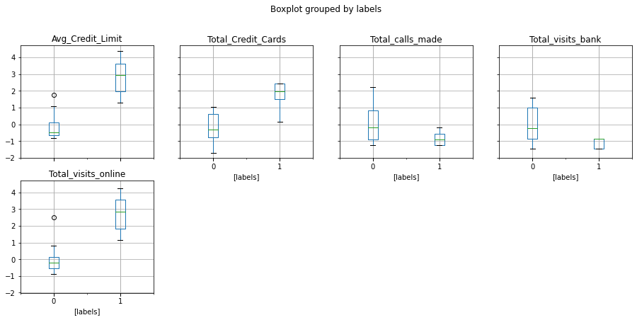

```python
# Visualize the centers
df_labeled_HC.boxplot(by = 'labels',  layout=(3,4), figsize=(15, 10))
```

Insights:

1. Customers with high avg credit limit, having more no. of credit cards, making less calls to the bank, visits bank less but who more visits online are belongs to label 1.
2. Customers with less avg credit limit, having less no. of credit cards,making more calls , who visits bank and visits online almost equal are belongs to label 0.

```python
silhouette_score(df_Scaled,model.labels_ , metric='euclidean')
```

```
0.5703183487340514
```

# Comparison of K-means clusters with Hierarchical clusters:

Comparison of K-means clusters with Hierarchical clusters:

In K-means clustering :

1. no. of cluster=3 with silhouette_score 51.57%.
2. Customers with high avg credit limit , have more no. of credit cards, often visit online and make less no. of calls to bank are belongs to label 2 .Customers with avg credit limit ,often visits Bank and making avearge no. of calls to the bank are belongs to label 1.Whereas,customers with low avg credit limit , have less no. of credit cards, and made more no. of calls to bank are belongs to label 0.

In Hierarchical clusters:

1. no. of cluster=2 with silhouette_score 57.03%.
2. Customers with high avg credit limit, having more no. of credit cards, making less calls to the bank, visits bank less but who more visits online are belongs to label 1.Whereas,customers with less avg credit limit, having less no. of credit cards,making more calls , who visits bank and visits online almost equal are belongs to label 0.

Hierarchical Clustering is better for identifying different segments in the existing customer based on their spending patterns as well as past interaction with the bank, as silhouette_score is 57.03%.

# Analysis of the clusters formed, tell us how is one cluster different from another:

1. In K-means clustering, no. of clusters formed is 3 and the customers are divided in clusters as: cluster1 386 cluster0 224 cluster2 50

   Customers with high avg credit limit , have more no. of credit cards, often visit online and make less no. of calls to bank are belongs to label 2 .Customers with avg credit limit ,often visits Bank and making avearge no. of calls to the bank are belongs to label 1. Whereas,customers with low avg credit limit , have less no. of credit cards, and made more no. of calls to bank are belongs to label 0.
2. In Hierarchical Clustering, no. of clusters formed is 2 and the customers are divided in clusters as: cluster0 610 cluster1 50

   Customers with high avg credit limit, having more no. of credit cards, making less calls to the bank, visits bank less but who more visits online are belongs to label 1.Whereas,customers with less avg credit limit, having less no. of credit cards,making more calls , who visits bank and visits online almost equal are belongs to label 0.

# Key Questions:

1. There are two or three different segments of customers.
2. How are these segments different from each other? In K-means clustering Customers with high avg credit limit , have more no. of credit cards, often visit online and make less no. of calls to bank are belongs to label 2 .Customers with avg credit limit ,often visits Bank and making avearge no. of calls to the bank are belongs to label 1. Whereas,customers with low avg credit limit , have less no. of credit cards, and made more no. of calls to bank are belongs to label 0.

   In Hierarchical Clustering Customers with high avg credit limit, having more no. of credit cards, making less calls to the bank, visits bank less but who more visits online are belongs to label 1.Whereas,customers with less avg credit limit, having less no. of credit cards,making more calls , who visits bank and visits online almost equal are belongs to label 0
3. What are your recommendations to the bank on how to better market to and service these customers? There are different channels through which customer has contacted the bank for any queries, different channels include visiting the bank, online and through a call. In order to upgrade the service delivery model, to ensure that customers queries are resolved faster, online customer service facility should be increased, more information should be provided to the customer on call. And when a customer visits a bank with a query, it should be resolved quickly.